# Covid91 vaccine study Final2021

Chris Panchame

Spring 2021

# 1 Introduction

A new preventative vaccine (covid91) is under test in clinical trials. Given the nature of this vaccine it is suspected that the drug may exhibit different effectiveness across the variety of subpopulations tracked. Consider population subgroups consisting of Males, Females, just the drug users, and just those in the LGBTQ community. Write a complete report that separately considers this drug for each subgroup and your recommendations as to whether people in the subgroup should take the vaccine. Structure your report in four sections each devoted to one of the four subgroups, use null and alternative hypothesis statements and correct statistical verbage when referencing p-values in conclusions.

The first step is to isolate the subpopulations of Male, Females, Drug Users, and LGBTQ.

# 2 Males

```r
Maledata<-filter(FinalData,sex=="guy")
Maledata$sex<-as.factor(Maledata$sex)
Maledata$infected=factor(Maledata$infected)
Maledata$infected<-relevel(Maledata$infected,"OK")
```

## 2.1 Barchart

```r
Males <- Maledata %>% group_by(infected, treatment) %>% summarize(count=n()) %>% mutate(prcnt=count/sum(count))
```

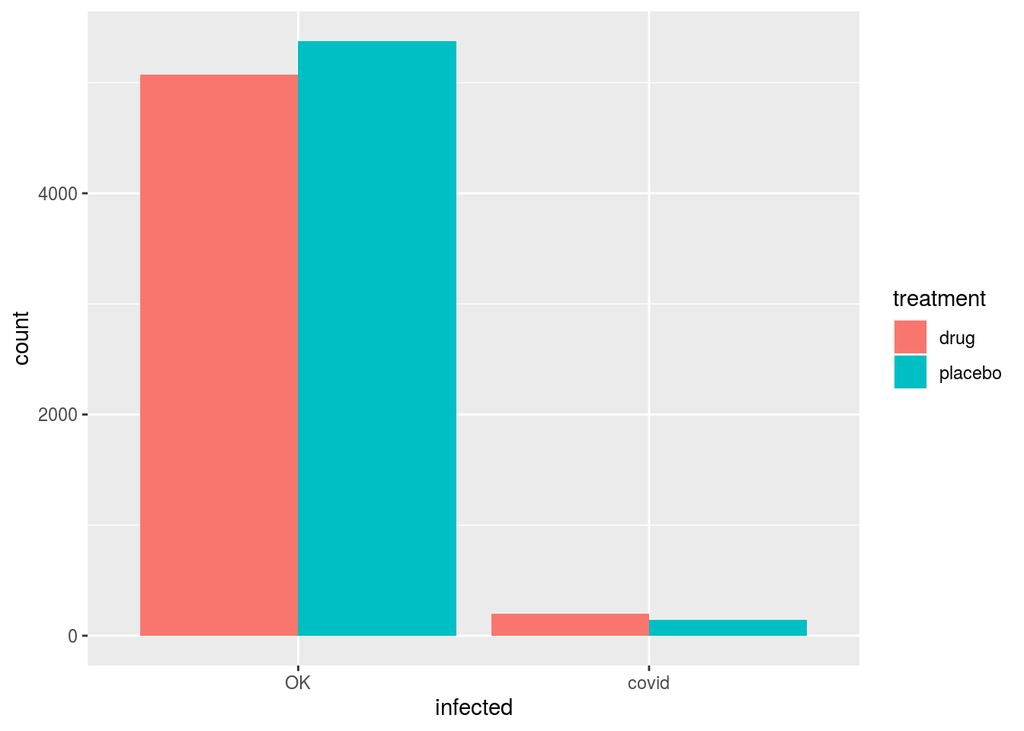

```r
# the group_by followed by summarize(count=n())

basicC <- ggplot(Males,aes(x=infected,y=count,fill=treatment))
basicC + geom_bar(stat="identity",position="dodge")
```

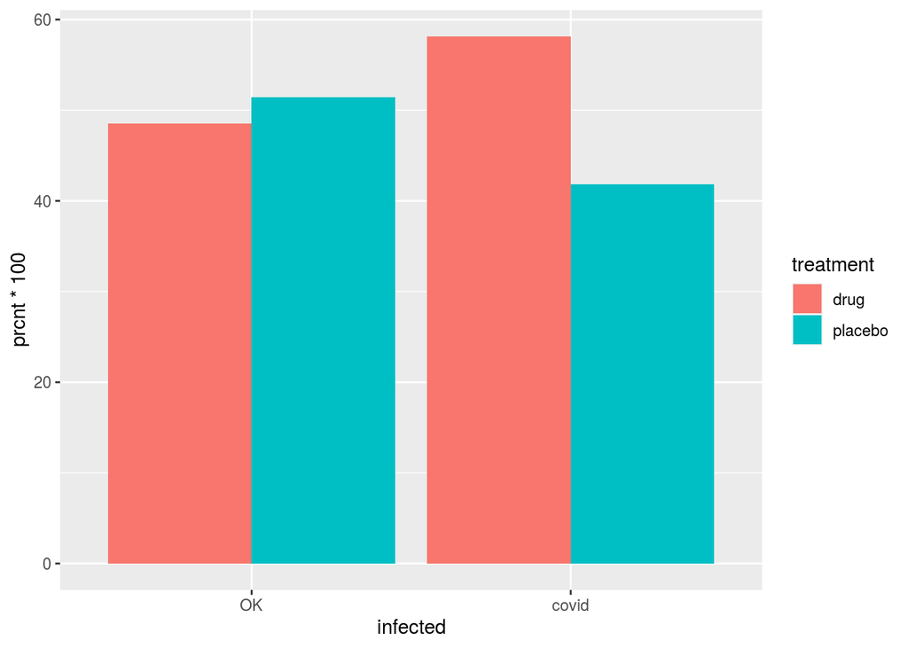

```r
#Now for percentage plot

basicCC <- ggplot(Males,aes(x=infected,y=prcnt*100,fill=treatment))
basicCC + geom_bar(stat="identity", position = "dodge")
```

This barchart shows that out of the approximately 340 Males who were infected with Covid 57% were given the drug, and 43% were give the placebo.

## 2.2 Numerical Summaries

```r
table1 <- xtabs(~treatment + infected, data=Maledata)
rowPerc(table1)
```

```
##          infected
## treatment     OK  covid  Total
##   drug     96.28   3.72 100.00
##   placebo  97.45   2.55 100.00
```

```r
colPerc(table1)
```

```
##          infected
## treatment     OK  covid
##   drug     48.54  58.16
##   placebo  51.46  41.84
##   Total   100.00 100.00
```

```r
print(table1)
```

```
##          infected
## treatment   OK covid
##   drug    5072   196
##   placebo 5378   141
```

## 2.3 Inferential

```r
chisq.test(table1)
```

```
##
##  Pearson's Chi-squared test with Yates' continuity correction
##
## data:  table1
## X-squared = 11.721, df = 1, p-value = 0.0006181
```

```r
chisqtestGC(table1)
```

```
## Pearson's Chi-squared test with Yates' continuity correction
##
## Observed Counts:
##          infected
## treatment   OK covid
##   drug    5072   196
##   placebo 5378   141
##
## Counts Expected by Null:
##          infected
## treatment      OK  covid
##   drug    5103.42 164.58
##   placebo 5346.58 172.42
##
## Contributions to the chi-square statistic:
##          infected
## treatment   OK covid
##   drug    0.19  6.00
##   placebo 0.18  5.73
##
##
## Chi-Square Statistic = 11.7206
## Degrees of Freedom of the table = 1
## P-Value = 6e-04
```

```r
fisher.test(table1)
```

```
##
##  Fisher's Exact Test for Count Data
##
## data:  table1
## p-value = 0.0005801
## alternative hypothesis: true odds ratio is not equal to 1
## 95 percent confidence interval:
##  0.5406079 0.8497815
## sample estimates:
## odds ratio
##  0.6784848
```

The p-value is so small at 0.0006181 that it is highly unlikely that the results were by chance.

$H_0$ the null hypothesis is that the vaccine makes no difference in the male population whe it comes to contracting Covid-19.

$H_0$ the alternative hypothesis is that the vaccine in fact does make a difference in whether or not a male contracts Covid.

Therefore, we reject the null hypotheseis.

The vaccine is 40% effective in the male population, which is ineffective.

# 3 Females

```r
Femaledata<-filter(FinalData,sex=="gal")
Femaledata$sex<-as.factor(Femaledata$sex)
Femaledata$infected=factor(Femaledata$infected)
Femaledata$infected<-relevel(Femaledata$infected,"OK")
levels(Femaledata$infected)
```

```
## [1] "OK"    "covid"
```

## 3.1 Barchart

```r
Females <- Femaledata %>% group_by(infected, treatment) %>% summarize(count=n()) %>% mutate(prcnt=count/sum(count))
```

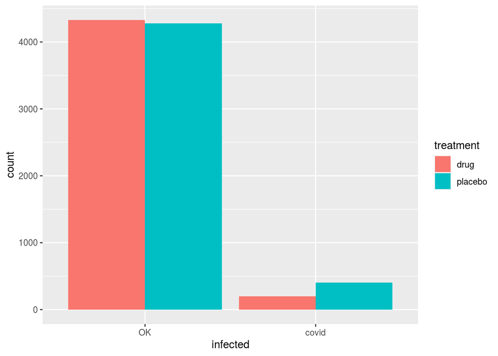

```r
# the group_by followed by summarize(count=n())

basicC <- ggplot(Females,aes(x=infected,y=count,fill=treatment))
basicC + geom_bar(stat="identity",position="dodge")
```

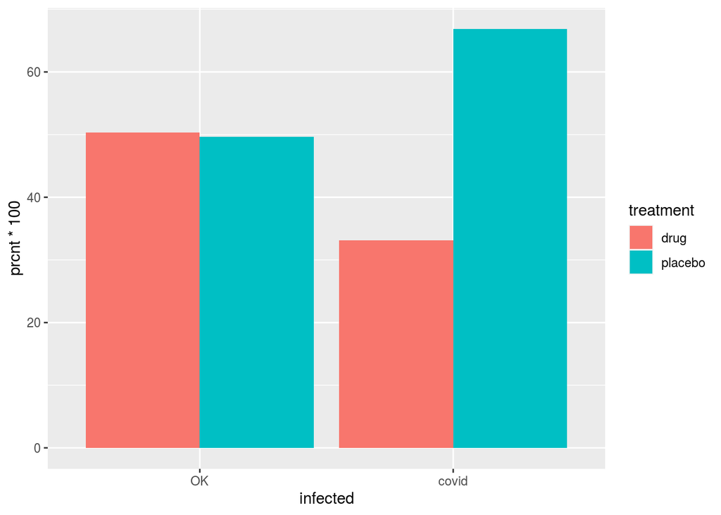

```r
#Now for percentage plot

basicCC <- ggplot(Females,aes(x=infected,y=prcnt*100,fill=treatment))
basicCC + geom_bar(stat="identity", position = "dodge")
```

This barchart shows that out of the approximately 607 females who were infected with Covid, 32% were given the drug and 66% were given the placebo.

## 3.2 Numerical Summaries

```r
table2 <- xtabs(~treatment + infected, data=Femaledata)
rowPerc(table2)
```

```
##          infected
## treatment     OK  covid  Total
##   drug     95.56   4.44 100.00
##   placebo  91.33   8.67 100.00
```

```r
colPerc(table2)
```

```
##          infected
## treatment     OK  covid
##   drug     50.31  33.11
##   placebo  49.69  66.89
##   Total   100.00 100.00
```

```r
print(table2)
```

```
##          infected
## treatment   OK covid
##   drug    4330   201
##   placebo 4276   406
```

## 3.3 Inferential

```r
chisq.test(table2)
```

```
##
##  Pearson's Chi-squared test with Yates' continuity correction
##
## data:  table2
## X-squared = 66.43, df = 1, p-value = 3.626e-16
```

```r
chisqtestGC(table2)
```

```
## Pearson's Chi-squared test with Yates' continuity correction
##
## Observed Counts:
##          infected
## treatment   OK covid
##   drug    4330   201
##   placebo 4276   406
##
## Counts Expected by Null:
##          infected
## treatment      OK  covid
##   drug    4232.47 298.53
##   placebo 4373.53 308.47
##
## Contributions to the chi-square statistic:
##          infected
## treatment    OK covid
##   drug     2.25 31.86
##   placebo  2.17 30.83
##
##
## Chi-Square Statistic = 66.4295
## Degrees of Freedom of the table = 1
## P-Value = 0
```

```r
fisher.test(table2)
```

```
##
##  Fisher's Exact Test for Count Data
##
## data:  table2
## p-value < 2.2e-16
## alternative hypothesis: true odds ratio is not equal to 1
## 95 percent confidence interval:
##  1.713470 2.447107
## sample estimates:
## odds ratio
##   2.045239
```

The p-value is so small that it is highly unlikely that the results were by chance.

$H_0$ The null hypothesis is that the vaccine makes no difference in the female population when it comes to contracting Covid-19.

$H_0$ the alternative hypothesis is that the vaccine in fact makes a difference in whether or not a female contracts Covid.

Therefore, we reject the null hypothesis.

The Fisher Exact Test odds ratio is 2.05:1, when taking the odds ration and computing it into a percent of effectiveness by using the formula 0/(1-0)*100 you get 67% effectiveness.

Ultimately the vaccine is 67% effective in the female population, which is absolutely effective.

# 4 Drug Users

# 5 Method

```r
druguserdata<-filter(FinalData,DrugUser=="yes")
druguserdata$sex<-as.factor(druguserdata$sex)
druguserdata$infected=factor(druguserdata$infected)
druguserdata$infected<-relevel(druguserdata$infected,"OK")
```

## 5.1 Barchart

```r
DrugUser <- druguserdata %>% group_by(infected, treatment) %>% summarize(count=n()) %>% mutate(prcnt=count/sum(count))
```

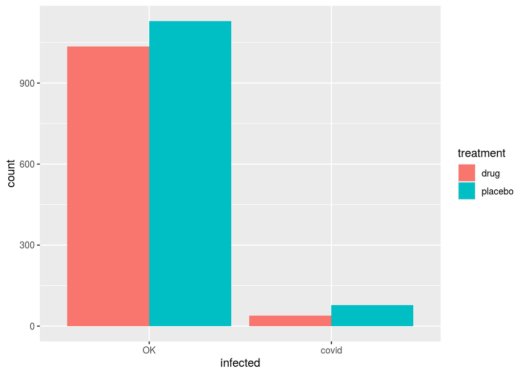

```r
# the group_by followed by summarize(count=n())

basicC <- ggplot(DrugUser,aes(x=infected,y=count,fill=treatment))
basicC + geom_bar(stat="identity",position="dodge")
```

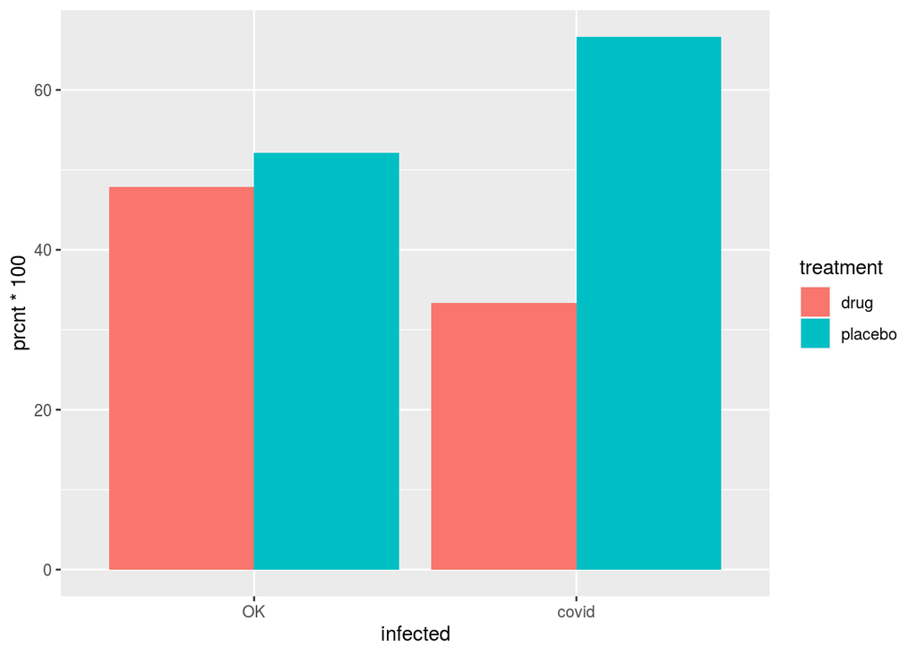

```r
#Now for percentage plot

basicCC <- ggplot(DrugUser,aes(x=infected,y=prcnt*100,fill=treatment))
basicCC + geom_bar(stat="identity", position = "dodge")
```

This barchart shows that out of the approximately 117 DrugUsers who were infected with Covid, 32% were given the drug and 66% were given the placebo.

## 5.2 Numerical Summaries

```r
table3 <- xtabs(~treatment + infected, data=druguserdata)
rowPerc(table3)
```

```
##          infected
## treatment     OK  covid  Total
##   drug     96.37   3.63 100.00
##   placebo  93.54   6.46 100.00
```

```r
colPerc(table3)
```

```
##          infected
## treatment     OK  covid
##   drug     47.83  33.33
##   placebo  52.17  66.67
##   Total   100.00 100.00
```

```r
print(table3)
```

```
##          infected
## treatment   OK covid
##   drug    1036    39
##   placebo 1130    78
```

## 5.3 Inferential

```r
chisq.test(table3)
```

```
##
##  Pearson's Chi-squared test with Yates' continuity correction
##
## data:  table3
## X-squared = 8.7902, df = 1, p-value = 0.003028
```

```r
chisqtestGC(table3)
```

```
## Pearson's Chi-squared test with Yates' continuity correction
##
## Observed Counts:
##          infected
## treatment   OK covid
##   drug    1036    39
##   placebo 1130    78
##
## Counts Expected by Null:
##          infected
## treatment      OK covid
##   drug    1019.91 55.09
##   placebo 1146.09 61.91
##
## Contributions to the chi-square statistic:
##          infected
## treatment   OK covid
##   drug    0.25  4.70
##   placebo 0.23  4.18
##
##
## Chi-Square Statistic = 8.7902
## Degrees of Freedom of the table = 1
## P-Value = 0.003
```

```r
fisher.test(table3)
```

```
##
##  Fisher's Exact Test for Count Data
##
## data:  table3
## p-value = 0.002273
## alternative hypothesis: true odds ratio is not equal to 1
## 95 percent confidence interval:
##  1.220336 2.792730
## sample estimates:
## odds ratio
##   1.833149
```

The p-value is so small at 0.002273 that is highlyunlikely that the results were by chance.

$H_0$ the null hypothesis is that the vaccine makes no difference in the DrugUser population when it comes to contracting Covid-19.

Therefore, we reject the null hypothesis.